# STATS506_hw4

## f.

Use the following code to tell Stata that the data is from a complex sample:

```
svyset CaseID [pw=weight_pop]
```

(Modify `CaseID` and `weight_pop` as appropriate if you have different variable names; those names are taken from the Codebook.)

Carry out a logisitic regression model accounting for the complex survey design. Be sure to treat variables you think should be categorical appropriately. From these results, provide an answer to the researchers question of interest.

Notice that the model does not provide a pseudo-R^2. R has the functionality to do this.

In this case, we take **nd2** as a discrete numeric variable, meaning that as the value goes up from 1 to 5, the respondent becomes more positive about future natural environment.

We also take **B7_a** and **ppeducat** as discrete numeric variables, meaning that as the value goes up, the economic condition goes higher or the education level of the respondent goes higher.

We take **gh1** and **race_5cat** as categorical variables.

```r
svyset caseid [pw=weight_pop]

svy: logistic b3 nd2 b7_a i.gh1 ppeducat i.race_5cat
```

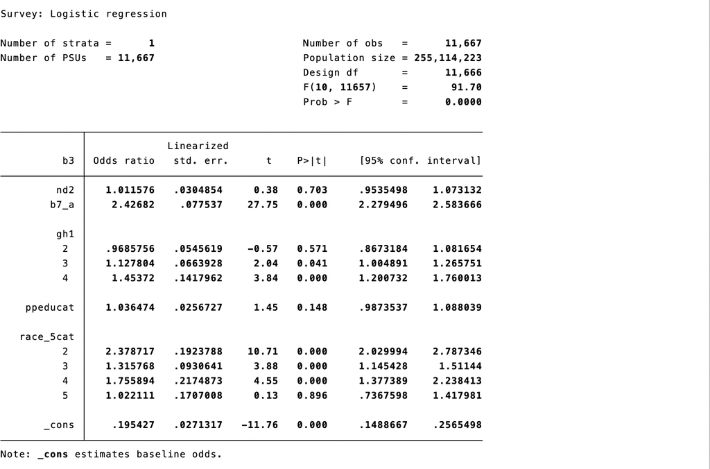

With other four variables held constant, the respondent’s family is better off, the same, or worse off finanicially compared to 12 month’s ago *cannot be predicted by* thinking that the chance of experiencing a natural disaster or severe weather event will be higher, lower or about the same in 5 years.

## h. Use the `survey` package to obtain the pseudo R^2. Use the following code to set up the complex survey design:

```r
public2022 <- read.csv('public2022_reg.csv')
```

```r
head(public2022)
```

```
  caseid weight_pop b3 nd2 b7_a gh1 ppeducat race_5cat
1      1   12033.68  1   2    2   3        4         1
2      2   21579.21  1   3    2   2        4         1
3      3   20043.89  1   3    2   3        3         3
4      4   21793.37  0   3    1   3        4         1
5      5   13900.41  0   1    3   1        4         1
6      6   19712.66  0   3    2   1        2         1
```

```r
install.packages('survey')
```

[output not shown]

```r
library(survey)
```

```r
design <- svydesign(id = ~ caseid, weight = ~ weight_pop, data = public2022)
```

```r
logit_mod <- svyglm(b3 ~ nd2 + b7_a + factor(gh1) + ppeducat + factor(race_5cat), data = public2022, family = binomial(link="logit"), design=design)
summary(logit_mod)
```

```
Call:
svyglm(formula = b3 ~ nd2 + b7_a + factor(gh1) + ppeducat + factor(race_5cat),
    design = design, family = binomial(link = "logit"), data = public2022)

Survey design:
svydesign(id = ~caseid, weight = ~weight_pop, data = public2022)

Coefficients:
                   Estimate Std. Error t value Pr(>|t|)
(Intercept)        -1.63257    0.13883 -11.759  < 2e-16 ***
nd2                 0.01151    0.03014   0.382 0.702545
b7_a                0.88658    0.03195  27.749  < 2e-16 ***
factor(gh1)2       -0.03193    0.05633  -0.567 0.570864
factor(gh1)3        0.12027    0.05887   2.043 0.041070 *
factor(gh1)4        0.37413    0.09754   3.836 0.000126 ***
ppeducat            0.03582    0.02477   1.446 0.148107
factor(race_5cat)2  0.86656    0.08088  10.715  < 2e-16 ***
factor(race_5cat)3  0.27442    0.07073   3.880 0.000105 ***
factor(race_5cat)4  0.56298    0.12386   4.545 5.54e-06 ***
factor(race_5cat)5  0.02187    0.16701   0.131 0.895814
---
Signif. codes:  0 '***' 0.001 '**' 0.01 '*' 0.05 '.' 0.1 ' ' 1

(Dispersion parameter for binomial family taken to be 0.998838)

Number of Fisher Scoring iterations: 4
```

```r
install.packages("rsq")
```

[output not shown]

```r
library(rsq)
```

```r
pseudo_R2_mcfadden <- rsq(logit_mod)
print(pseudo_R2_mcfadden)
```

```
[1] 0.1082127
```